# EIS 2024 vs. 2026

A Weighted Trend Comparison

Last updated September 18, 2026 at 11:01 AM

## Methodology

This report compares the 2024 and 2026 fields of the Election Information Survey on every question the two instruments asked in a genuinely comparable way, using `output/eis_cumulative.rds` (built by `eis_2026_04_cumulative_data.R`).

Every estimate below uses `weight_common`, not each year’s own delivered weight. Morning Consult changed the registered-voter weighting targets substantially between the two fields — the no-bachelor’s-degree target moved from 40.6% to 57.6%, and the White share of the target moved from 58.6% to 76.4% — while the raw, unweighted samples barely moved at all. Because education and race correlate with the subject of this survey, comparing each year’s own weighted numbers directly would mix real opinion change with an artifact of the target change itself. `weight_common` re-rakes both years to one shared demographic target, while preserving each year’s own recalled-presidential-vote margin, so a difference in the charts below reflects a real difference between 2024 and 2026 respondents, not a difference in what each year’s weight was correcting toward.

Where the estimate is a proportion or a mean, the shaded whisker around each dot is a 95% confidence interval, calculated with the `survey` package on the `weight_common` design. Where the comparison is a rank rather than a raw level — noted explicitly in the source-seeking section — no confidence interval is shown, because a rank has no standard error of its own; the percentages underlying that ranking are given in a table instead.

## Is the Country Headed in the Right Direction?

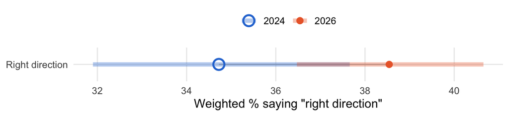

## Most Important Issue

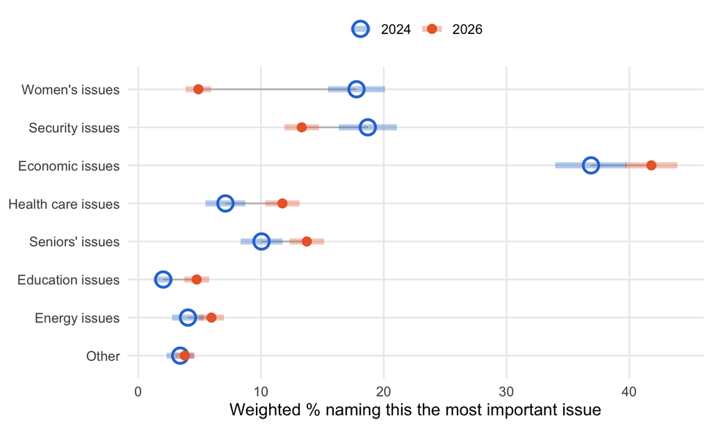

## How Often Voters Seek Election Information

Shown as the full weighted distribution across all five frequency categories, not collapsed to a single cutoff — these categories are ordered (more/less often) but not evenly spaced, so a weighted mean would treat unequal gaps as if they were equal.

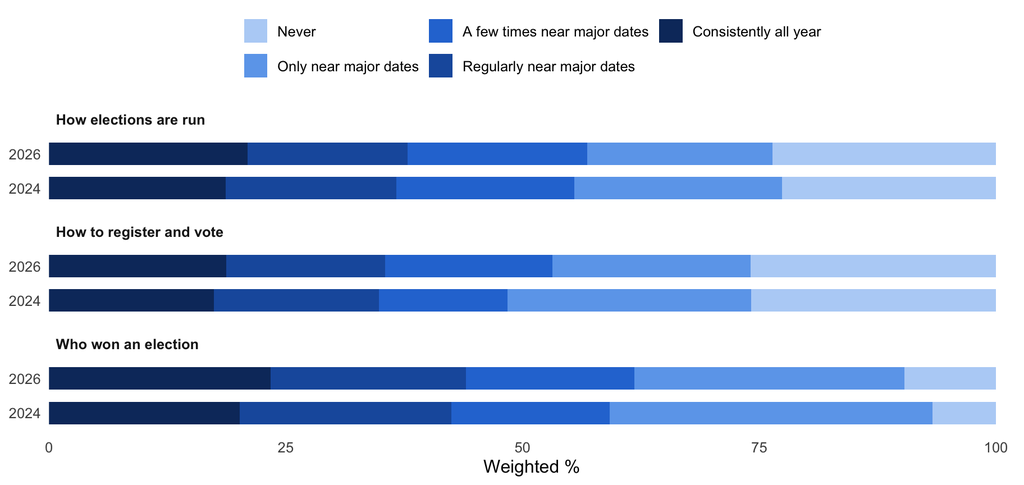

## Where Voters Look for Election Information

Both years cap respondents at three selections, but the menus behind that cap differ in size — 2026 added two heavily-selected options (an online search engine and an AI chatbot) with no 2024 counterpart, and because the cap is shared, those two compete with the eight indicators below for the same three slots. A raw level change in any of the eight is therefore partly menu displacement, not opinion change. The rank each source holds within its own year is more robust to this than the raw percentage is, so rank is the primary comparison here; the underlying weighted percentages (with 95% CIs) are given in the table under each chart for reference.

### Register and vote

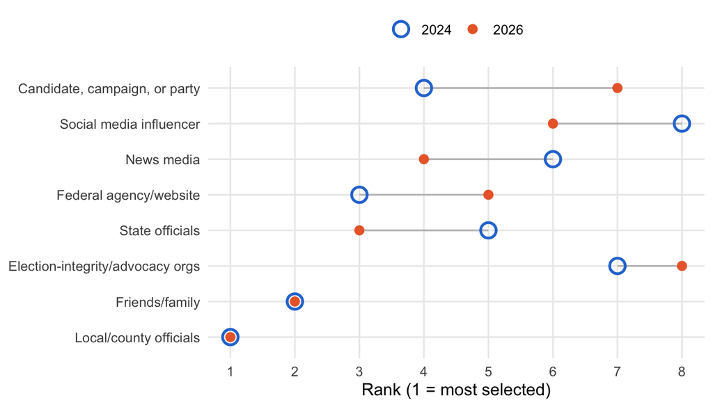

| Source | Year | Weighted % | 95% CI | Rank |
| --- | --- | --- | --- | --- |
| Candidate, campaign, or party | 2024 | 21.2 | 18.7–24 | 4 |
| Candidate, campaign, or party | 2026 | 8.0 | 7–9.2 | 7 |
| Election-integrity/advocacy orgs | 2024 | 16.6 | 14.4–19 | 7 |
| Election-integrity/advocacy orgs | 2026 | 5.9 | 5–6.9 | 8 |
| Federal agency/website | 2024 | 24.4 | 22–27 | 3 |
| Federal agency/website | 2026 | 16.4 | 14.9–18 | 5 |
| Friends/family | 2024 | 24.7 | 22.2–27.4 | 2 |
| Friends/family | 2026 | 23.4 | 21.6–25.3 | 2 |
| Local/county officials | 2024 | 27.7 | 25.1–30.5 | 1 |
| Local/county officials | 2026 | 32.6 | 30.6–34.6 | 1 |
| News media | 2024 | 19.1 | 16.8–21.7 | 6 |
| News media | 2026 | 17.7 | 16.2–19.4 | 4 |
| Social media influencer | 2024 | 9.3 | 7.6–11.3 | 8 |
| Social media influencer | 2026 | 13.0 | 11.6–14.5 | 6 |
| State officials | 2024 | 21.0 | 18.6–23.5 | 5 |
| State officials | 2026 | 20.1 | 18.5–21.9 | 3 |

### How elections are run

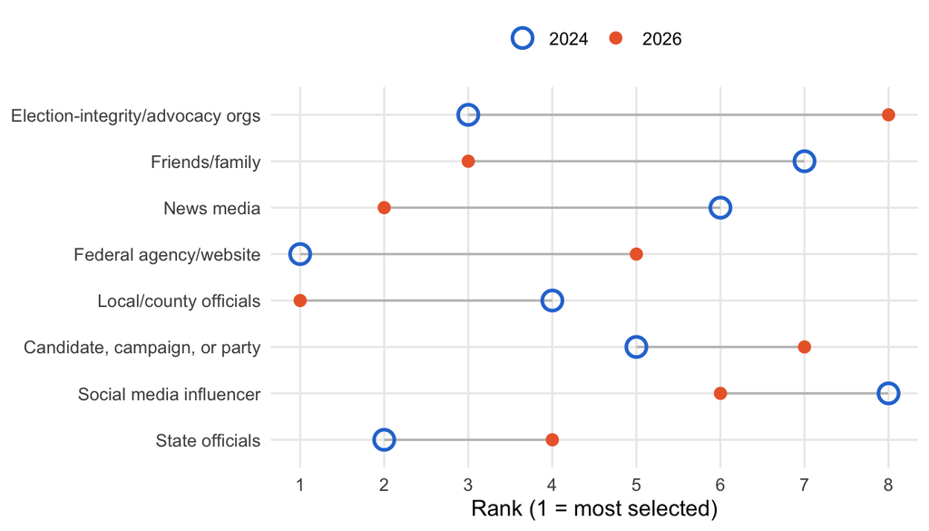

| Source | Year | Weighted % | 95% CI | Rank |
| --- | --- | --- | --- | --- |
| Candidate, campaign, or party | 2024 | 17.9 | 15.7–20.4 | 5 |
| Candidate, campaign, or party | 2026 | 8.9 | 7.7–10.1 | 7 |
| Election-integrity/advocacy orgs | 2024 | 20.3 | 18.1–22.8 | 3 |
| Election-integrity/advocacy orgs | 2026 | 8.4 | 7.3–9.6 | 8 |
| Federal agency/website | 2024 | 33.5 | 30.7–36.4 | 1 |
| Federal agency/website | 2026 | 17.7 | 16.1–19.4 | 5 |
| Friends/family | 2024 | 16.4 | 14.3–18.8 | 7 |
| Friends/family | 2026 | 19.3 | 17.7–21.1 | 3 |
| Local/county officials | 2024 | 18.6 | 16.4–21 | 4 |
| Local/county officials | 2026 | 24.6 | 22.9–26.5 | 1 |
| News media | 2024 | 17.7 | 15.5–20.1 | 6 |
| News media | 2026 | 24.2 | 22.4–26 | 2 |
| Social media influencer | 2024 | 9.1 | 7.4–11.1 | 8 |
| Social media influencer | 2026 | 14.1 | 12.7–15.7 | 6 |
| State officials | 2024 | 23.0 | 20.6–25.7 | 2 |
| State officials | 2026 | 19.1 | 17.5–20.8 | 4 |

### Who won

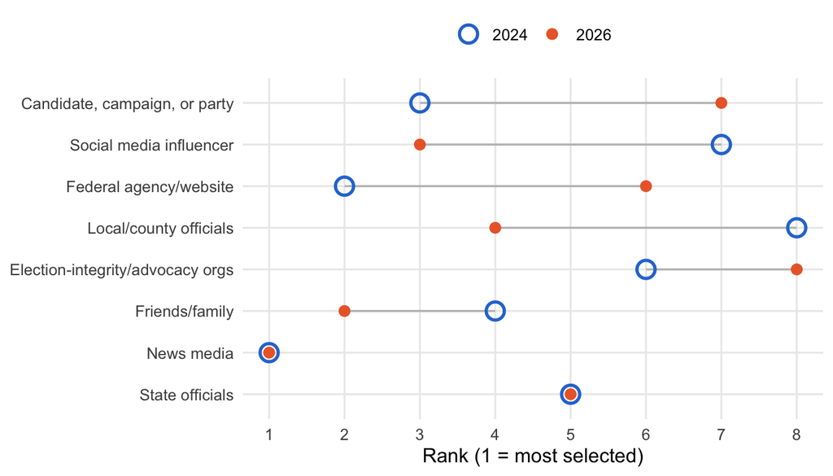

| Source | Year | Weighted % | 95% CI | Rank |
| --- | --- | --- | --- | --- |
| Candidate, campaign, or party | 2024 | 18.5 | 16.2–21 | 3 |
| Candidate, campaign, or party | 2026 | 8.3 | 7.2–9.5 | 7 |
| Election-integrity/advocacy orgs | 2024 | 13.1 | 11.1–15.5 | 6 |
| Election-integrity/advocacy orgs | 2026 | 4.8 | 3.9–5.8 | 8 |
| Federal agency/website | 2024 | 20.0 | 17.7–22.4 | 2 |
| Federal agency/website | 2026 | 11.2 | 9.9–12.6 | 6 |
| Friends/family | 2024 | 15.9 | 13.9–18.2 | 4 |
| Friends/family | 2026 | 19.4 | 17.7–21.1 | 2 |
| Local/county officials | 2024 | 9.9 | 8.3–11.8 | 8 |
| Local/county officials | 2026 | 16.0 | 14.5–17.6 | 4 |
| News media | 2024 | 49.4 | 46.3–52.4 | 1 |
| News media | 2026 | 50.7 | 48.5–52.8 | 1 |
| Social media influencer | 2024 | 12.7 | 10.8–15 | 7 |
| Social media influencer | 2026 | 19.3 | 17.7–21.1 | 3 |
| State officials | 2024 | 13.4 | 11.5–15.6 | 5 |
| State officials | 2026 | 13.1 | 11.8–14.6 | 5 |

## Attitudes Toward AI Use in Elections

Two views of the same ten items. The first treats each item’s 1-5 “very bad thing” to “very good thing” score as a mean — a simplification, since the scale is ordinal and the gaps between its categories are not guaranteed to be equal. The second avoids that assumption by collapsing to three categories (bad / neither / good) and showing the weighted proportions directly.

### Mean score (1-5)

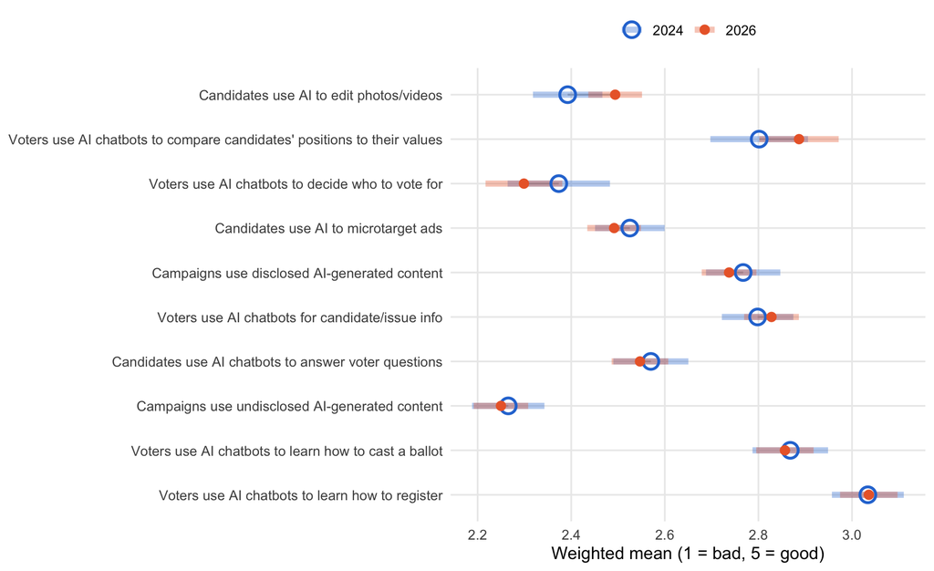

### Weighted proportions (bad / neither / good)

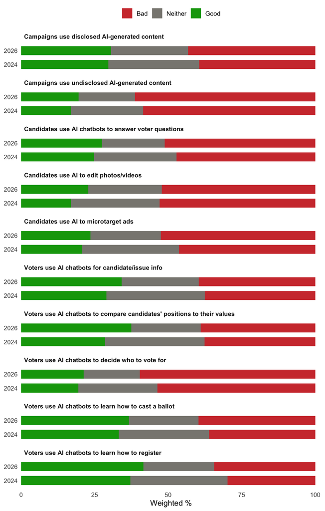

## Voting Experience

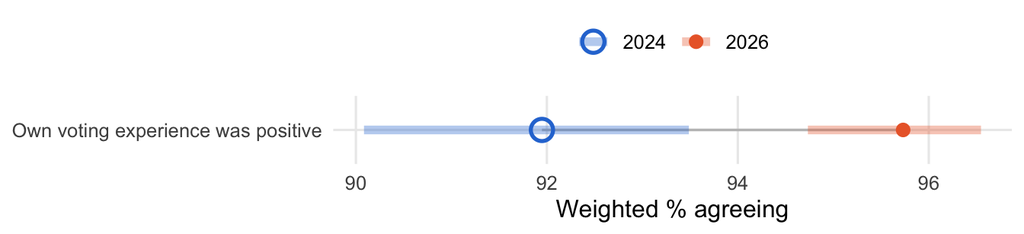

## Confidence Votes Will Be Counted as Intended

“Confident” combines “somewhat confident” and “very confident” into one weighted percentage — the same convention `eis_2026_03_common_weights.R`’s `compare_years()` helper uses for these same items. Three of the four items are a clean four-point scale in both years. The fourth, confidence in your own vote, is not: 2026’s wording (`BPC40`) adds a fifth option, “I do not plan to vote in the November 2026 midterm elections,” that 2024’s wording (`BPC20`) does not have. The 97 respondents who chose it are excluded from this item’s base in 2026, the same way “don’t know” respondents are excluded from every item’s base in both years — so the percentage below is out of everyone who gave a substantive confidence answer, not out of everyone who took the survey.

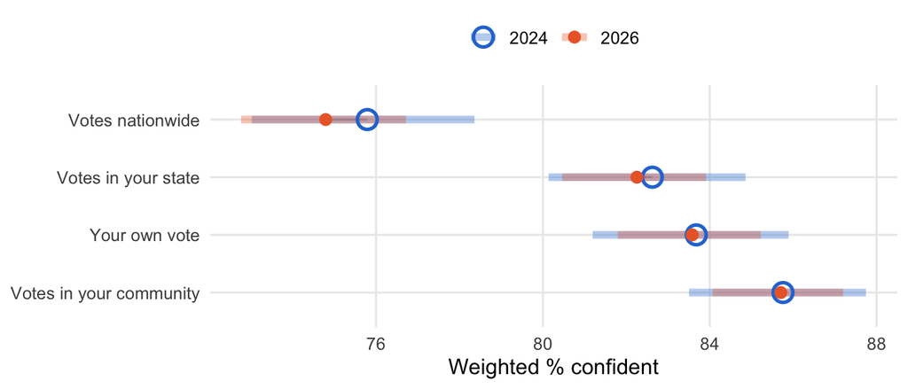

## Concern About Election Problems

“Concerned” combines “somewhat concerned” and “very concerned,” the two upper categories of the four-point scale, into one weighted percentage.

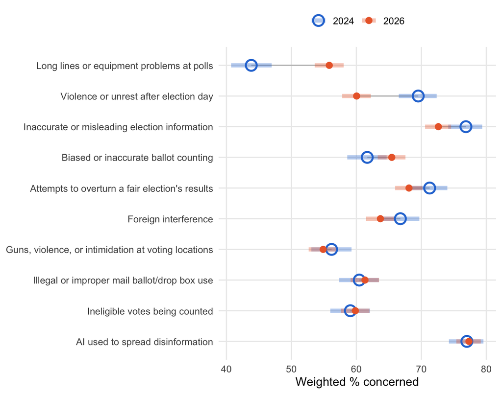